# Final Project

Matt Goldsmith

November 25, 2018

## Summary

To predict the “classe” variable we decided to use Random Forests. First we had to match the columns and levels of the training and testing sets because Random Forest will not work otherwise. For cross-validation, we split the training set into a train/test subset. Overall, the Random Forest that used only the most important variables performed well on the Test data.

## Load & Split Train into Train/Test subsets for Cross-Validation

```r
#load data
train <- read.csv("https://d396qusza40orc.cloudfront.net/predmachlearn/pml-training.csv",na.strings=c("","NA"))

#Data for Quiz
test <- read.csv("https://d396qusza40orc.cloudfront.net/predmachlearn/pml-testing.csv",na.strings=c("","NA"))

#Remove columns with NA (Test set) & Match Train/Test Columns_Names/Levels
test2 <- test[,colSums(is.na(test)) == 0]
name1 <- colnames(test2)
train2 <- train[,colnames(train) %in% name1]

common <- intersect(names(train2), names(test2))
for (p in common) {
  if (class(train2[[p]]) == "factor") {
    levels(test2[[p]]) <- levels(train2[[p]])
  }
}

train3 <- cbind(train2, train$classe)
names(train3) <- c(name1[1:59], "classe")



#Subset Train into train/test for cross-validation
set.seed(888)
x <- sample(1:nrow(train3), 0.7*nrow(train3))
sub_train <- train3[x,]
sub_test <- train3[-x,]
```

## Random Forest

#### Initial Random Forest (all variables)

```r
library(randomForest)
t_names <- names(test2)
f <- paste(t_names[5:59],collapse = "+")
ff <- as.formula(paste("classe", f, sep = "~"))
rf1 <- randomForest(ff, data=sub_train)
yhat1 <- predict(rf1, newdata = sub_test)
table(yhat1,sub_test$classe)
```

```
##
## yhat1    A    B    C    D    E
##     A 1690    2    0    0    0
##     B    0 1183    1    0    0
##     C    0    1 1042    4    0
##     D    0    0    0  924    7
##     E    0    0    0    0 1033
```

```r
correct1 <- ifelse(yhat1 == sub_test$classe,1,0)
acc <- sum(correct1)/length(correct1)
acc
```

```
## [1] 0.997452
```

In the table above and with the calculated accuracy of 99.7%, we can see that our initial model did very well at predicting “classe” using all variables available in Test set.

#### Subset training data to most significant variables from initial random forest

In Figure 1 in Appendix, we can see that the most significant variable is cvtd_timestamp, followed by num_window and roll_belt. Now we will select only the most important variables and re-run a random forest.

```r
z <- importance(rf1)
z_names <- row.names(z)
#take variables with importance >= 250
z1 <- ifelse(z>=250,1,0)
z2 <- as.data.frame(cbind(z_names, z1,z))
z3 <- z2[z2$MeanDecreaseGini == 1, ]
```

#### Second Random Forest (importance >= 250)

```r
t_names <- as.vector(z3$z_names)
f <- paste(t_names,collapse = "+")
ff <- as.formula(paste("classe", f, sep = "~"))
rf2 <- randomForest(ff, data=sub_train)
yhat2 <- predict(rf2, newdata = sub_test)
table(yhat2,sub_test$classe)
```

```
##
## yhat2    A    B    C    D    E
##     A 1690    0    0    0    0
##     B    0 1186    1    0    0
##     C    0    0 1042    0    0
##     D    0    0    0  928    6
##     E    0    0    0    0 1034
```

```r
correct2 <- ifelse(yhat2 == sub_test$classe,1,0)
acc2 <- sum(correct2)/length(correct2)
acc
```

```
## [1] 0.997452
```

Based on the two random forest’s above, I predict my model will have a 90%+ accuracy on the Test data.

## Course Project Prediction Quiz

```r
levels(test2) <- levels(sub_train)

##using RF2
quiz <- predict(rf2, newdata = test2)

#Quiz Answers
quiz
```

```
##  1  2  3  4  5  6  7  8  9 10 11 12 13 14 15 16 17 18 19 20
##  B  A  B  A  A  E  D  B  A  A  B  C  B  A  E  E  E  B  A  B
## Levels: A B C D E
```

## Appendix

##### Figure 1

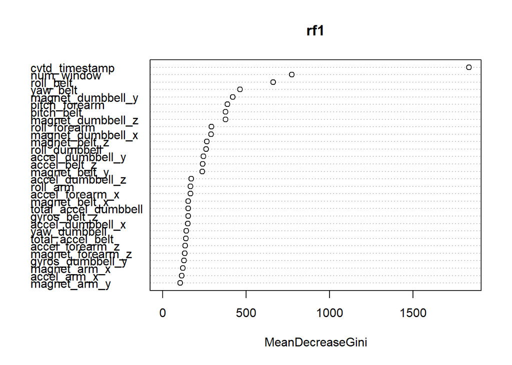

```r
varImpPlot(rf1)
```

##### Figure 2

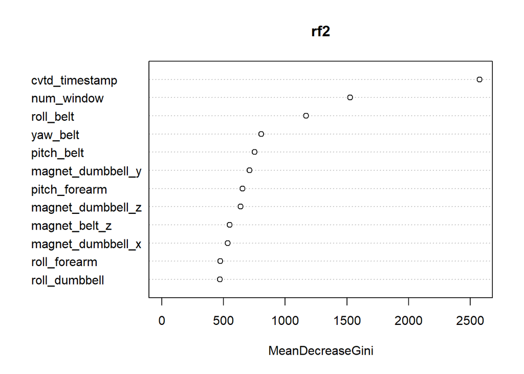

```r
varImpPlot(rf2)
```